```r
library(tidyverse)
library(here)
```

# Simulation specs

This is a simulation to compare the scaled vs unscaled embeddings. The simulation shares all the same parameters except for the values of the embeddings. The parameters are as following:

```
BATCH_INFO = {
    "jitter_n": 1,
    "total_batch_n": 1,
    "jitter_mode": "sampling"
}

GRID_INFO = {
    "grid_mu_start": -4, "grid_mu_end": 4, "grid_mu_step": 5,
    "grid_sigma_start": 0.001, "grid_sigma_end": 1.8, "grid_sigma_step": 5,
    "grid_y_start": -4, "grid_y_end": 4, "grid_y_step": 5,
    "grid_epsilon_start": 0.00000000001, "grid_epsilon_end": 1, "grid_epsilon_step": 5,
    "hypothetical_obs_grid_n": 10
}


BATCH_GRID_INFO = num_stab_help.get_batch_grid(BATCH_INFO, GRID_INFO)

PRIOR_INFO = {
    "mu_prior": 1,
    "V_prior": 1,
    "alpha_prior": 3,
    "beta_prior": 1,
    "epsilon": 0.0001, "mu_epsilon":0.0001, "sd_epsilon": 0.0001,
    "hypothetical_obs_grid_n": 5,
    "world_EIGs": 0.00001, "max_observation": 500
}
```

And for the stimuli, the scaled stimuli are:

```
fam: tensor([-0.2870,  0.2874,  0.3432], dtype=torch.float64) test: tensor([-0.4805, -0.9730, -0.2181], dtype=torch.float64)
```

and the unscaled are 10x of the original

```
fam: tensor([-2.870,  2.874,  3.432], dtype=torch.float64) test: tensor([-4.805, -9.730, -2.181], dtype=torch.float64)
```

Each consisted of 50 run of the same simulation, The stimuli squence are BBBBD

Below are the comparisons

```r
library(tidyverse)
library(here)

eig_df <- read_csv(here("scaled_vs_unscaled/eig_df.csv"))
```

```
## ──────────────────────────────────────────────────────── Delimiter: "," dbl
## (4): ...1, stimulus_id, EIG, run_id lgl (4): Look_away, surprisal, kl, prob
```

```r
sim_df <- read_csv(here("scaled_vs_unscaled/sim_df.csv"))
```

```
## ──────────────────────────────────────────────────────── Delimiter: "," dbl
## (3): ...1, sample_n, run_id
```

```r
x10_eig_df <- read_csv(here("scaled_vs_unscaled/x10_eig_df.csv"))
```

```
## ──────────────────────────────────────────────────────── Delimiter: "," dbl
## (4): ...1, stimulus_id, EIG, run_id lgl (4): Look_away, surprisal, kl, prob
```

```r
x10_sim_df <- read_csv(here("scaled_vs_unscaled/x10_sim_df.csv"))
```

```
## ──────────────────────────────────────────────────────── Delimiter: "," dbl
## (3): ...1, sample_n, run_id
```

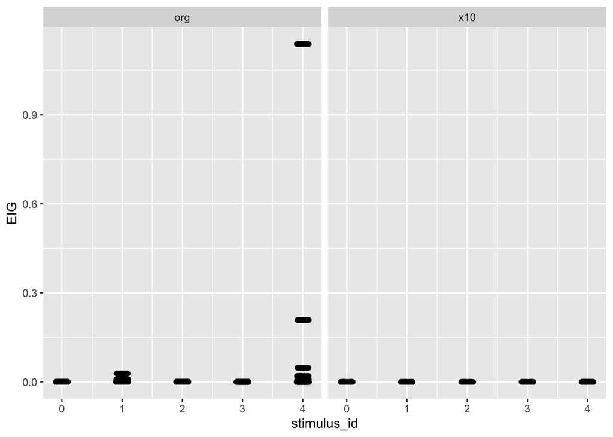

```r
eig_df %>%
  mutate("type" = "org") %>%
  filter(!is.na(stimulus_id)) %>%
  bind_rows(
    x10_eig_df %>%
      mutate("type" = "x10") %>%
      filter(!is.na(stimulus_id))
  ) %>%
  group_by(type, run_id) %>%
  mutate(t = row_number()) %>%
  ggplot(aes(x = stimulus_id, y = EIG)) +
  geom_point(position = position_jitter(width=.1))+
  facet_wrap(~type)
```

we can also check on invalid values (i.e. the number of rows with EIG < 0).

```r
eig_df %>%
  filter(EIG < 0) %>%
  count()
```

```
## # A tibble: 1 × 1
##       n
##   <int>
## 1     0
```

```r
x10_eig_df %>%
  filter(EIG < 0) %>%
  group_by(stimulus_id) %>%
  count()
```

```
## # A tibble: 1 × 2
## # Groups:   stimulus_id [1]
##   stimulus_id     n
##         <dbl> <int>
## 1           4    50
```

Then we can look at the trajectories. The originals doesn’t look quite right, maybe due to the prior? no clear habituation but very clear dishabituation

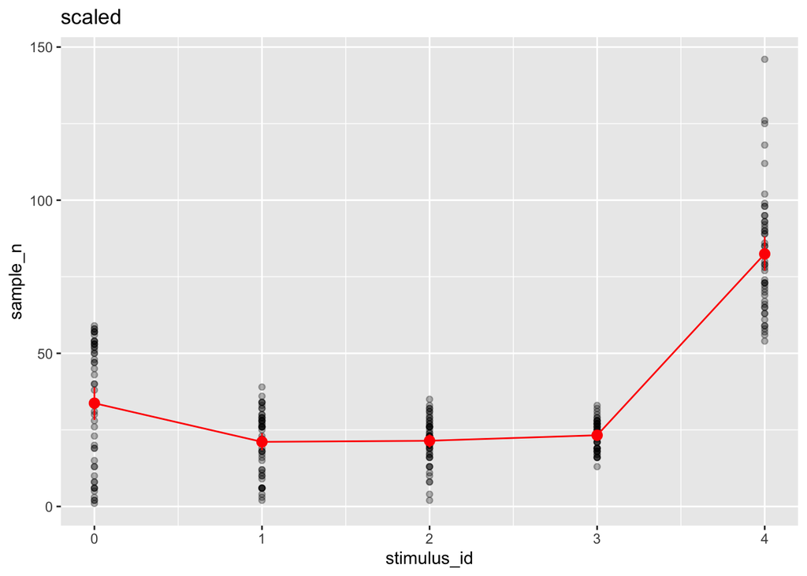

```r
sim_df %>%
  rename(stimulus_id = `...1`) %>%
  ggplot(aes(x = stimulus_id, y = sample_n)) +
  geom_point(alpha = .3) +
  stat_summary(fun.data = "mean_cl_boot", color = "red") +
  stat_summary(fun.data = "mean_cl_boot", geom = "line", color = "red") +
  labs(title = "scaled")
```

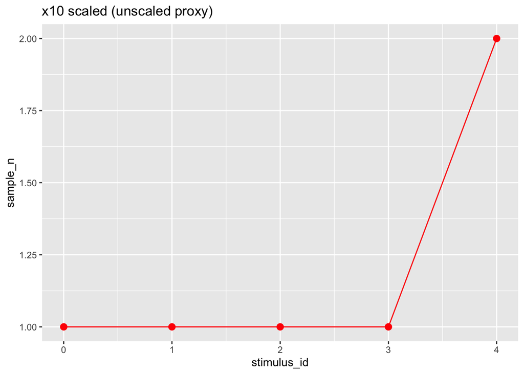

```r
x10_sim_df %>%
  rename(stimulus_id = `...1`) %>%
  ggplot(aes(x = stimulus_id, y = sample_n)) +
  geom_point(alpha = .3) +
  stat_summary(fun.data = "mean_cl_boot", color = "red") +
  stat_summary(fun.data = "mean_cl_boot", geom = "line", color = "red") +
  labs(title = "x10 scaled (unscaled proxy)")
```

it turns out there was no variation for the unscaled version at all. all backgrounds have 1 sample, and deviant has 2 samples. persumably due to the last trial always having negative number.

```r
x10_sim_df
```

```
## # A tibble: 250 × 3
##     ...1 sample_n run_id
##    <dbl>    <dbl>  <dbl>
##  1     0        1      0
##  2     1        1      0
##  3     2        1      0
##  4     3        1      0
##  5     4        2      0
##  6     0        1      1
##  7     1        1      1
##  8     2        1      1
##  9     3        1      1
## 10     4        2      1
## # ℹ 240 more rows
```